# Introducción a la Econometría para Finanzas

## Trabajo Práctico Nro 1 - 1º Trimestre 2025

#### Universidad Torcuato Di Tella

##### Francisco Ciocchini - Bárbara Guerezta

## CONSIGNAS

### Instrucciones

```
. El trabajo práctico es de entrega obligatoria.
. Se puede realizar en grupos de no más de 4 personas.
. Se realiza una sola entrega por grupo indicando los nombres de todos los integrantes.
. La fecha límite de entrega es el día miércoles 23 de abril de 2025 a las 23.59hs.
. Deberá subirse al campus de la facultad el html (o pdf si lo prefiere) creado con RMarkdown que contenga los códigos utilizados para la resolución del trabajo.
. Por cualquier consulta pueden escribir a bguerezta@gmail.com
```

```python
import pandas as pd
import statsmodels.formula.api as smf
from statsmodels.iolib.summary2 import summary_col #Útil para presentar muchas regresiones a la vez
import matplotlib.pyplot as plt
```

## Problema 1: Estimación del $\beta$ de un activo

### Enunciado

El $\beta$ de un activo es lo que comúnmente se conoce como la sensibilidad de los retornos de un activo relativo a un índice de referencia, que, en el caso de las acciones, típicamente es el índice S&P 500.\

Si lo representamos en una ecuación, ésta sería:

$$ \begin{aligned} R^e_{t}=\alpha +\beta R^e_{M,t} + \mu_t \end{aligned} $$ donde $R^e_{M,t}$ es el exceso de retorno del portafolio de mercado (S&P 500) en el período $t$ y $R^e_{t}$ es el exceso de retorno de un activo en el período $t$.\

Tomando datos de Rachev et al., Financial Econometrics, Chapter 3, replicaremos los resultados presentados en clase.

1. El archivo "Financial_Econometrics_data.pdf" contiene un extracto del Capítulo 3 que deberemos replicar (también pueden encontrar los resultados en la clase teórica correspondiente).
2. El archivo de excel "Financial_Econometrics_data.xlsx" contiene datos desde diciembre 2000 y noviembre 2005 con retornos mensuales anualizados de distintos activos: SandP representa al índice S&P 500, Rf corresponde a la tasa libre de riesgo de un bono del tesoro norteamericano (Treasury) a 90 días, GM hace referencia al retorno de la acción de General Motors, Oracle, al de Oracle, y Portfolio es una cartera integrada por 20 acciones (Honeywell, Alcoa, Campbell, Boeing, General Dynamics, Oracle, Sun, General Motors, Procter & Gamble, Wal-Mart, Exxon, ITT, Unilever, Hilton, Martin Marietta, Coca-Cola, Northrop Grumman, Mercury Interact, Amazon, and United Technologies). Importen ese archivo a Python, y cree un dataframe.
3. Para cada una de los índices que vamos a estudiar (S&P, Oracle, GM, Portfolio), computen el exceso de retorno con respecto a la tasa libre de riesgo a 90 días.
4. Análisis Gráfico. Realicen tres gráficos de líneas que comparen, de a pares el exceso de retorno de Oracle con S&P, de GM con S&P, y del Portfolio con S&P, a lo largo del tiempo. Describan lo que ven. La librería Matplotlib puede ser útil: https://matplotlib.org/stable/gallery/subplots_axes_and_figures/subplots_demo.html
5. Análisis Gráfico II: Realicen tres gráficos de dispersión para comparar el exceso de retorno de Oracle contra S&P, de GM contra S&P, y de Portfolio contra S&P. Descríbanlos. la librería matplotlib puede ser útil.
6. Utilizando la librería de statsmodels vista en clase, estimen 3 regresiones univariadas para computar el $beta$ de Oracle, GM y la cartera de 20 activos, replicando el modelo presentado más arriba en este problema. Presenten una tabla donde se puedan ver, al menos, los valores estimados de cada uno de esos 3 regresiones, el desvío estándar y el p-valor asociado. Pueden usar la librería stargazzer, o la función summary_col dentro del paquete de statsmodels, o alguno similar.
7. Evalúe para cada modelo si el $\beta$ es significativamente distinto de 1 con un 95% de confianza. ¿Por qué no puede utilizar el p-value calculado por default en la estimación del modelo del punto anterior? Interprete el significado de que un activo tenga un $\beta$ igual a 1.

*Hint*: el punto 7 se puede realizar a mano copiando manualmente los resultados del punto anterior, si quisieran, pero si estiman por statmodels, cada modelo almacena los parámetros computados en la regresión bajo la forma de series, que pueden ser extraídos. Por ejemplo, si el modelo se llama "m1", pueden extraer los beta estimados utilizando m1.params; y cada elemento corresponde al beta estimado. Lo mismo ocurre con los desvíos estándares (bse) o con los p-value (pvalues). Les dejamos algunos comandos de python útiles en la sección de soluciones por si quieren explorarlo. Los que lo hagan, tendrán algún bonus en la evaluación.

### Solución Problema 1

#### Ejercicio 1.2

El archivo de excel "Financial_Econometrics_data.xlsx" contiene datos desde diciembre 2000 y noviembre 2005 con retornos mensuales anualizados de distintos activos: SandP representa al índice S&P 500, Rf corresponde a la tasa libre de riesgo de un bono del tesoro norteamericano (Treasury) a 90 días, GM hace referencia al retorno de la acción de General Motors, Oracle, al de Oracle, y Portfolio es una cartera integrada por 20 acciones (Honeywell, Alcoa, Campbell, Boeing, General Dynamics, Oracle, Sun, General Motors, Procter & Gamble, Wal-Mart, Exxon, ITT, Unilever, Hilton, Martin Marietta, Coca-Cola, Northrop Grumman, Mercury Interact, Amazon, and United Technologies). Importen ese archivo a Python, y cree un dataframe.

```python
import pandas as pd
#################
# Ejercicio 1.2 #
#################

# Importar datos
from google.colab import drive
#drive.mount('/content/drive')
#path = '/content/drive/MyDrive/UTDT/02_Introducción a la Econometría para Finanzas/03_Practicas/01_Practica/Financial_Econometrics_data.xlsx'
#retornos = pd.read_excel(path)
!gdown --id 1gRX_OoWM68bQN8iQbCwQ3H1gm3UcAfAI
retornos = pd.read_excel('Financial_Econometrics_data.xlsx')
retornos.set_index("Date", inplace=True)

retornos.head()
```

| Date | SandP_R | Rf | Oracle_R | GM_R | Portfolio_R |
| --- | --- | --- | --- | --- | --- |
| 2000-12-01 | 0.03464 | 0.00473 | 0.00206 | 0.05418 | 0.01446 |
| 2001-01-01 | -0.09229 | 0.00413 | -0.34753 | -0.00708 | -0.07324 |
| 2001-02-01 | -0.06420 | 0.00393 | -0.21158 | -0.02757 | -0.07029 |
| 2001-03-01 | 0.07681 | 0.00357 | 0.07877 | 0.05709 | 0.11492 |
| 2001-04-01 | 0.00509 | 0.00321 | -0.05322 | 0.03813 | 0.01942 |

#### Ejercicio 1.3

Para cada una de los índices que vamos a estudiar (S&P, Oracle, GM, Portfolio), computen el exceso de retorno con respecto a la tasa libre de riesgo a 90 días.

```python
#################
# Ejercicio 1.3 #
#################

# Calcular exceso de retorno para cada activo
retornos["Exceso_SP"] = retornos["SandP_R"] - retornos["Rf"]
retornos["Exceso_Oracle"] = retornos["Oracle_R"] - retornos["Rf"]
retornos["Exceso_GM"] = retornos["GM_R"] - retornos["Rf"]
retornos["Exceso_Portfolio"] = retornos["Portfolio_R"] - retornos["Rf"]

retornos.head()
```

| Date | SandP_R | Rf | Oracle_R | GM_R | Portfolio_R | Exceso_SP | Exceso_Oracle | Exceso_GM | Exceso_Portfolio |
| --- | --- | --- | --- | --- | --- | --- | --- | --- | --- |
| 2000-12-01 | 0.03464 | 0.00473 | 0.00206 | 0.05418 | 0.01446 | 0.02991 | -0.00267 | 0.04945 | 0.00973 |
| 2001-01-01 | -0.09229 | 0.00413 | -0.34753 | -0.00708 | -0.07324 | -0.09642 | -0.35166 | -0.01121 | -0.07737 |
| 2001-02-01 | -0.06420 | 0.00393 | -0.21158 | -0.02757 | -0.07029 | -0.06813 | -0.21551 | -0.03150 | -0.07422 |
| 2001-03-01 | 0.07681 | 0.00357 | 0.07877 | 0.05709 | 0.11492 | 0.07324 | 0.07520 | 0.05352 | 0.11135 |
| 2001-04-01 | 0.00509 | 0.00321 | -0.05322 | 0.03813 | 0.01942 | 0.00188 | -0.05643 | 0.03492 | 0.01621 |

#### Ejercicio 1.4

Análisis Gráfico. Realicen tres gráficos de líneas que comparen, de a pares el exceso de retorno de Oracle con S&P, de GM con S&P, y del Portfolio con S&P, a lo largo del tiempo. Describan lo que ven. La librería Matplotlib puede ser útil: https://matplotlib.org/stable/gallery/subplots_axes_and_figures/subplots_demo.html

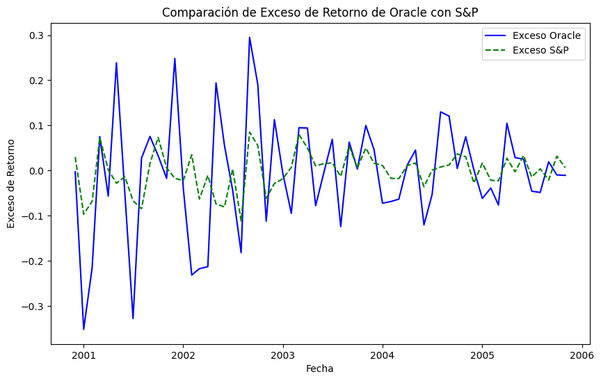

```python
import matplotlib.pyplot as plt # Import the matplotlib library
#################
#################
# Ejercicio 1.4 #
#################

# Crear los gráficos de líneas para las comparaciones
plt.figure(figsize=(10, 6))

# Graficar Oracle vs S&P
plt.plot(retornos.index, retornos["Exceso_Oracle"], label="Exceso Oracle", color='blue')
plt.plot(retornos.index, retornos["Exceso_SP"], label="Exceso S&P", linestyle='--', color='green')

# Personalizar el gráfico
plt.title("Comparación de Exceso de Retorno de Oracle con S&P")
plt.xlabel("Fecha")
plt.ylabel("Exceso de Retorno")
plt.legend()

# Mostrar el gráfico
plt.show()
```

[figure not shown]

```python
# Crear los gráficos de líneas para las comparaciones
plt.figure(figsize=(10, 6))

# Graficar GM vs S&P
plt.plot(retornos.index, retornos["Exceso_GM"], label="Exceso GM", color='red')
plt.plot(retornos.index, retornos["Exceso_SP"], linestyle='--', color='green', label="Exceso Oracle")

# Personalizar el gráfico
plt.title("Comparación de Exceso de Retorno de GM con S&P")
plt.xlabel("Fecha")
plt.ylabel("Exceso de Retorno")
plt.legend()

# Mostrar el gráfico
plt.show()
```

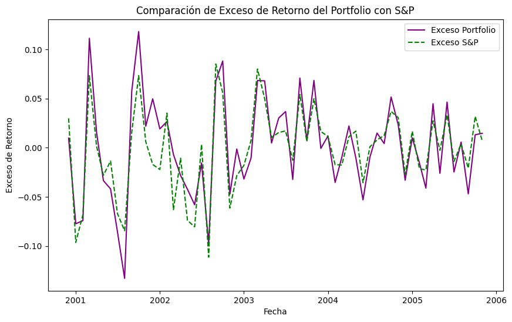

```python
# Crear los gráficos de líneas para las comparaciones
plt.figure(figsize=(10, 6))

# Graficar Portfolio vs S&P
plt.plot(retornos.index, retornos["Exceso_Portfolio"], label="Exceso Portfolio", color='purple')
plt.plot(retornos.index, retornos["Exceso_SP"], linestyle='--', color='green', label="Exceso S&P")

# Personalizar el gráfico
plt.title("Comparación de Exceso de Retorno del Portfolio con S&P")
plt.xlabel("Fecha")
plt.ylabel("Exceso de Retorno")
plt.legend()

# Mostrar el gráfico
plt.show()
```

#### Ejercicio 1.5

Análisis Gráfico II: Realicen tres gráficos de dispersión

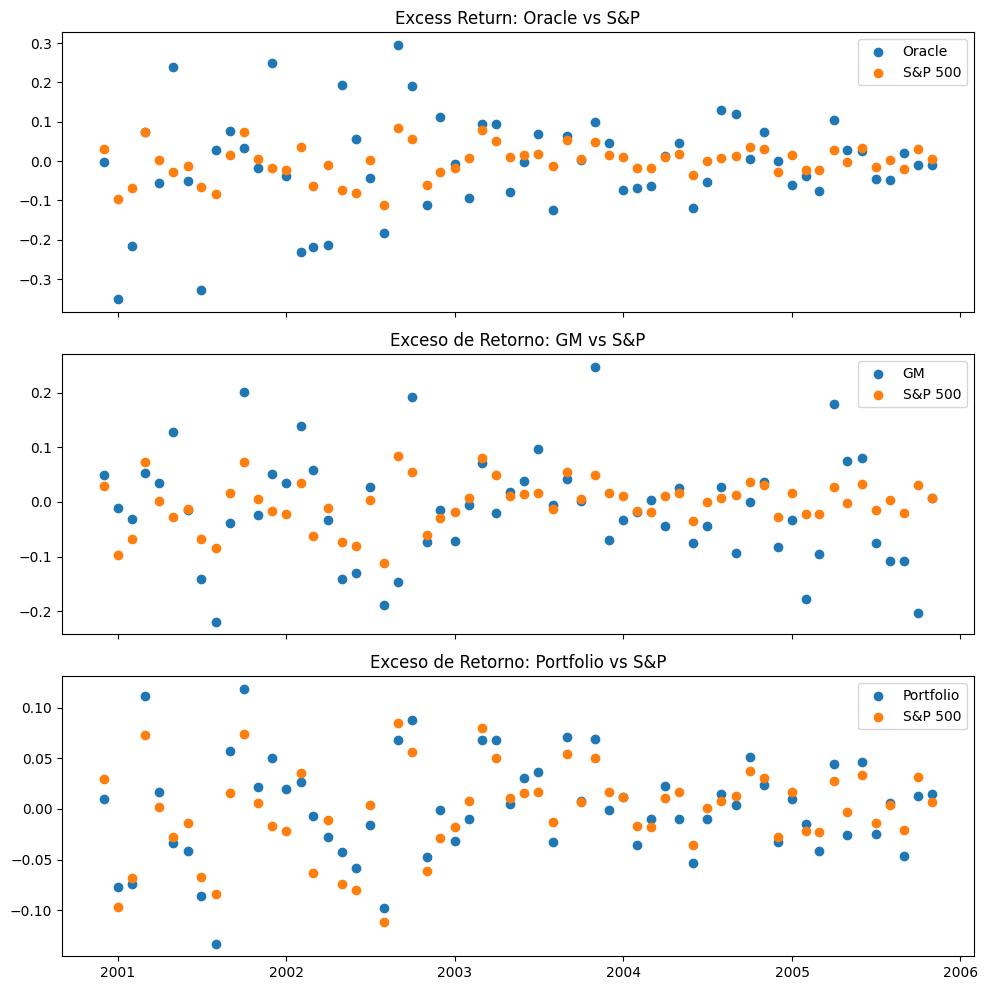

```python
#################
# Ejercicio 1.5 #
#################
fig, axs = plt.subplots(3, 1, figsize=(10, 10), sharex=True)

axs[0].scatter(retornos.index, retornos['Exceso_Oracle'], label='Oracle')
axs[0].scatter(retornos.index, retornos['Exceso_SP'], label='S&P 500')
axs[0].legend()
axs[0].set_title('Excess Return: Oracle vs S&P')

axs[1].scatter(retornos.index, retornos['Exceso_GM'], label='GM')
axs[1].scatter(retornos.index, retornos['Exceso_SP'], label='S&P 500')
axs[1].legend()
axs[1].set_title('Exceso de Retorno: GM vs S&P')

axs[2].scatter(retornos.index, retornos['Exceso_Portfolio'], label='Portfolio')
axs[2].scatter(retornos.index, retornos['Exceso_SP'], label='S&P 500')
axs[2].legend()
axs[2].set_title('Exceso de Retorno: Portfolio vs S&P')

plt.tight_layout()
plt.show()
```

#### Ejerecicio 1.6

Estimen 3 regresiones univariadas

```python
import statsmodels.formula.api as smf # Import
#################
# Ejercicio 1.6 #
#################
reg_gm = smf.ols(formula = "Exceso_GM ~ Exceso_SP", data = retornos)
results_gm = reg_gm.fit()
#print(results_gm.summary())

reg_oracle = smf.ols(formula = "Exceso_Oracle ~ Exceso_SP", data = retornos)
results_oracle = reg_oracle.fit()
#print(results_oracle.summary())

reg_portfolio = smf.ols(formula = "Exceso_Portfolio ~ Exceso_SP", data = retornos)
results_portfolio = reg_portfolio.fit()
#print(results_portfolio.summary())


summary_data = {
    "Model": ["GM", "Oracle", "Portfolio"],
    "Beta": [
        results_gm.params["Exceso_SP"],
        results_oracle.params["Exceso_SP"],
        results_portfolio.params["Exceso_SP"]
    ],
    "Std. Error": [
        results_gm.bse["Exceso_SP"],
        results_oracle.bse["Exceso_SP"],
        results_portfolio.bse["Exceso_SP"]
    ],
    "p-value": [
        results_gm.pvalues["Exceso_SP"],
        results_oracle.pvalues["Exceso_SP"],
        results_portfolio.pvalues["Exceso_SP"]
    ]
}

# Convert to DataFrame
summary_df = pd.DataFrame(summary_data)
print(summary_df)
```

```
       Model      Beta  Std. Error       p-value
0         GM  1.156747    0.257024  3.316437e-05
1     Oracle  1.405656    0.339376  1.132254e-04
2  Portfolio  1.026124    0.069753  3.117899e-21
```

#### Ejercicio 1.7

Evalúe para cada modelo si el $\beta$ es **significativamente distinto de 1** con un 95% de confianza. ¿Por qué no puede utilizar el p-value calculado por default en la estimación del modelo del punto anterior? Interprete el significado de que un activo tenga un $\beta$ igual a 1.

```python
#################
# Ejercicio 1.7 #
#################
f_test_gm =results_gm.f_test("Exceso_SP = 1")
print("F test GM. ", f_test_gm)
f_test_oracle=results_oracle.f_test("Exceso_SP = 1")
print("F test Oracle. ", f_test_oracle)
f_test_portfolio=results_portfolio.f_test("Exceso_SP = 1")
print("F test Portfolio. ", f_test_portfolio)
```

```
F test GM.  <F test: F=0.37192245920449774, p=0.5443402101546874, df_denom=58, df_num=1>
F test Oracle.  <F test: F=1.4287393611353818, p=0.2368348052981964, df_denom=58, df_num=1>
F test Portfolio.  <F test: F=0.1402628299707787, p=0.7093857143217385, df_denom=58, df_num=1>
```

Dado los resultados de los F-Test, no podemos rechazar la hipótesis nula a un 95% de confianza dado que ningún p-valor es menor a a 0.05. No podemos usar por default la estimación del modelo por que ese mismo es para testear si Beta es significativo o no, es decir, hipótesis nula Beta=0 . Si un activo tiene un Beta=1 esto significa que: el exceso de retorno del activo - por sobre el retorno libre de riesgo - se mueve similarmente al exceso de retorno del mercado por sobre el retorno libre de riesgo.

## Problema 2: Predicción de Spreads de Bonos Corporativos

### Enunciado

Consideremos el siguiente modelo:

$$ \begin{aligned} S_i = \beta_0 + \beta_1 CRate_i + \beta_2 CRatio_i + \beta_3 ln(EBIT_i) + \mu_i\\ \end{aligned} $$

donde: $S_i$ es el Spread de un bono de la empresa $i$ (en basis points)

$CRate_i$ es la tasa de cupón del bono de la empresa $i$ (en porcentaje),

$CRatio_i$ es el coverage ratio $i$ = $\frac{EBITDA_i}{InterestExpense_i}$,

$lnEBIT_i$ es el logaritmo natural de $EBIT$ de la empresa $i$, con $EBIT_i$ expresado en millones de dólares. \

1. El archivo spread_data.xlsx incluye datos extraídos del Capítulo 4 de Rachev et al. Financial Econometrics. **Impórtenlo a Python.**
2. Estimen por **mínimos cuadrados ordinarios** la ecuación presentada previamente y muestren los **resultados** de la estimación, con errores robustos a la presencia de heteroscedasticidad. \
3. Interpreten el **significado de cada uno de los parámetros** estimados en la regresión anterior, teniendo en cuenta las unidades de medida de las variables.
4. Realicen una prueba de **significatividad conjunta** para $\beta_2$ y $\beta_3$. ( *Hint*: El modelo estimado en el punto 2 tiene una función asociada que se llama "f_test" que puede correr esta prueba sobre la hipótesis planteada.)
5. Evalúen el efecto sobre el spread de ser una compañía *investment grade*. Para ello computen primero una variable dicotómica que tome valor 1 cuando la variable *non_inv_grade* sea igual a 0.

Luego inclúyanla como una variable explicativa dentro del modelo anterior y vuelvan a estimarlo.

¿Es relevante su efecto? Expliquen el signo, la magnitud y la lógica económica detrás del resultado de la estimación.

### Solución Problema 2

#### Ejercicio 2.1

El archivo spread_data.xlsx incluye datos extraídos del Capítulo 4 de Rachev et al. Financial Econometrics. Impórtenlo a Python.

```python
#################
# Ejercicio 2.1 #
#################

# Importar datos
#from google.colab import drive
#drive.mount('/content/drive')
#path = '/content/drive/MyDrive/UTDT/02_Introducción a la Econometría para Finanzas/03_Practicas/01_Practica/spread_data.xlsx'

spreads = pd.read_excel('spread_data.xlsx')

spreads.head()
```

|  | id_bond | date | spread | non_inv_grade | coupon | cov_ratio | ln_ebit |
| --- | --- | --- | --- | --- | --- | --- | --- |
| 0 | 1 | nov-28-2005 | 509 | 0 | 7.400 | 2.085 | 2.121 |
| 1 | 2 | nov-28-2005 | 584 | 0 | 8.500 | 2.085 | 2.121 |
| 2 | 3 | nov-28-2005 | 247 | 0 | 8.375 | 9.603 | 2.507 |
| 3 | 4 | nov-28-2005 | 73 | 0 | 6.650 | 11.507 | 3.326 |
| 4 | 5 | nov-28-2005 | 156 | 0 | 7.125 | 11.507 | 3.326 |

#### Ejercicio 2.2

Estimen por mínimos cuadrados ordinarios la ecuación presentada previamente y muestren los resultados de la estimación, con errores robustos a la presencia de heteroscedasticidad. \

```python
#################
# Ejercicio 2.2 #
#################

# Estimar el modelo de regresión lineal con errores estándar robustos
model_1 = smf.ols('spread ~ coupon + cov_ratio + ln_ebit', data=spreads).fit(cov_type='HC1')

# Imprimir los resultados de la regresión
print(model_1.summary())
```

```
                            OLS Regression Results
==============================================================================
Dep. Variable:                 spread   R-squared:                       0.578
Model:                            OLS   Adj. R-squared:                  0.571
Method:                 Least Squares   F-statistic:                     62.69
Date:                Wed, 23 Apr 2025   Prob (F-statistic):           1.85e-28
Time:                        01:53:13   Log-Likelihood:                -1221.6
No. Observations:                 200   AIC:                             2451.
Df Residuals:                     196   BIC:                             2464.
Df Model:                           3
Covariance Type:                  HC1
==============================================================================
                 coef    std err          z      P>|z|      [0.025      0.975]
------------------------------------------------------------------------------
Intercept    157.0870     76.885      2.043      0.041       6.395     307.779
coupon        61.2746      8.427      7.271      0.000      44.757      77.792
cov_ratio    -13.2047      2.116     -6.240      0.000     -17.352      -9.057
ln_ebit      -90.9059     14.245     -6.381      0.000    -118.826     -62.985
==============================================================================
Omnibus:                       20.506   Durbin-Watson:                   1.633
Prob(Omnibus):                  0.000   Jarque-Bera (JB):               25.341
Skew:                           0.704   Prob(JB):                     3.14e-06
Kurtosis:                       4.030   Cond. No.                         114.
==============================================================================

Notes:
[1] Standard Errors are heteroscedasticity robust (HC1)
```

#### Ejercicio 2.3

Interpreten el significado de cada uno de los parámetros estimados en la regresión anterior, teniendo en cuenta las unidades de medida de las variables.

En la regresión estimada, todos los coeficientes son estadísticamente significativos (p-valor < 0.05) y con el signo esperado:

- **Un aumento de 1 punto porcentual en la tasa de cupón** se asocia con **un incremento de 61 puntos básicos en el spread**, lo que sugiere mayor riesgo percibido.
- Un mayor cov_ratio (mejor salud financiera) reduce el spread en 13 puntos básicos por unidad.
- Como ln_ebit es el logaritmo de EBIT, su coeficiente indica que un incremento del 1% en el EBIT está asociado con una reducción aproximada de 0.91 puntos básicos en el spread, lo que refleja que empresas más grandes y rentables enfrentan menores primas de riesgo.

#### Ejercicio 2.4

Realicen una prueba de significatividad conjunta para $\beta_2$ y $\beta_3$. *Hint*: El modelo estimado en el punto 2 tiene una función asociada que se llama "f_test" que puede correr esta prueba sobre la hipótesis planteada.

La prueba de significatividad conjunta para las variables cov_ratio y ln_ebit arroja un estadístico F de 49.72 con un valor p prácticamente nulo (p < 0.001), lo que indica que podemos rechazar la hipótesis nula de que ambos coeficientes son iguales a cero. En consecuencia, existe evidencia estadísticamente significativa de que al menos una de estas dos variables tiene un efecto sobre el spread del bono.

```python
#################
# Ejercicio 2.4 #
#################

# Prueba conjunta de cov_ratio y ln_ebit
f_test_result = model_1.f_test('cov_ratio = 0, ln_ebit = 0')
print(f_test_result)
```

```
<F test: F=49.71893817897367, p=3.430915715808395e-18, df_denom=196, df_num=2>
```

#### Ejercicio 2.5

Evalúen el efecto sobre el spread de ser una compañía *investment grade*. Para ello computen primero una variable dicotómica que tome valor 1 cuando la variable *non_inv_grade* sea igual a 0. Luego inclúyanla como una variable explicativa dentro del modelo anterior y vuelvan a estimarlo. ¿Es relevante su efecto? Expliquen el signo, la magnitud y la lógica económica detrás del resultado de la estimación.

El coeficiente de la variable inv_grade es negativo y estadísticamente significativo (p-valor = 0), lo que indica que los bonos con grado de inversión presentan, en promedio, un spread aproximadamente 265 puntos básicos menor que los bonos sin dicha calificación. Este resultado es consistente con la lógica económica, ya que los bonos más seguros implican un menor riesgo para los inversionistas, quienes por tanto exigen una menor prima por riesgo.

```python
# Crear un diccionario para invertir los valores de la variable 'non_inv_grade' para obtener la nueva variable 'inv_grade'
cambiar_inv_grade = {
    0: 1, # 0 pasa a 1
    1: 0 # 1 pasa a 0
}

# Crear la nueva variable 'inv_grade' aplicando el mapeo sobre 'non_inv_grade'
spreads['inv_grade'] = spreads['non_inv_grade'].map(cambiar_inv_grade)

# Estimar un nuevo modelo de regresión lineal que incluye 'inv_grade' como variable explicativa
model_2 = smf.ols('spread ~ coupon + cov_ratio + ln_ebit + inv_grade', data=spreads).fit(cov_type='HC1')

# Mostrar el resumen de resultados del nuevo modelo
print(model_2.summary())
```

```
                            OLS Regression Results
==============================================================================
Dep. Variable:                 spread   R-squared:                       0.730
Model:                            OLS   Adj. R-squared:                  0.724
Method:                 Least Squares   F-statistic:                     76.78
Date:                Wed, 23 Apr 2025   Prob (F-statistic):           5.39e-39
Time:                        01:55:00   Log-Likelihood:                -1177.0
No. Observations:                 200   AIC:                             2364.
Df Residuals:                     195   BIC:                             2380.
Df Model:                           4
Covariance Type:                  HC1
==============================================================================
                 coef    std err          z      P>|z|      [0.025      0.975]
------------------------------------------------------------------------------
Intercept    559.6980     74.530      7.510      0.000     413.622     705.774
coupon        34.3559      6.472      5.308      0.000      21.671      47.041
cov_ratio    -10.5375      1.603     -6.573      0.000     -13.680      -7.395
ln_ebit      -79.4396     12.292     -6.463      0.000    -103.531     -55.348
inv_grade   -264.7126     33.128     -7.991      0.000    -329.642    -199.783
==============================================================================
Omnibus:                        1.895   Durbin-Watson:                   1.941
Prob(Omnibus):                  0.388   Jarque-Bera (JB):                1.638
Skew:                           0.217   Prob(JB):                        0.441
Kurtosis:                       3.088   Cond. No.                         131.
==============================================================================

Notes:
[1] Standard Errors are heteroscedasticity robust (HC1)
```

## Problema 3 - Event Studies: Rescate de Credit Suisse

### Enunciado

El 19 de marzo del año 2023 se firmó un acuerdo mediante el cual la compañía suiza de servicios financieros y bancarios creado en el año 1856, Credit Suisse, pasaría a formar parte de otro banco suizo, UBS. El objetivo de este problema es identificar si este anuncio tuvo algún impacto sobre el precio de la acción de UBS.

Para responder a esta pregunta se puede estimar un modelo bajo el supuesto de que se cumple CAPM:

$$R_{UBS,t} = \alpha + \beta R_{M,t} + \gamma_{1} D1_t + \gamma_2 D2_t + \gamma_3 D3_t + \gamma_4 D4_t + \gamma_5 D5_t + \gamma_6 D6_t + \mu_t$$ donde

$R_{UBS,t}$ es el retorno de UBS en el día $t$  
$R_{M,t}$ es el retorno del índice SPY, que es un ETF que replica la composición del índice accionario S&P 500 - 500 grandes empresas que poseen acciones que cotizan en las bolsas NYSE o NASDAQ - (ie, "retorno del mercado") en el día $t$  
$D1_t$ es una *dummy* que toma valor 1 en el día 16-marzo-2023 (ie, 2 días hábiles antes del anuncio)  
$D2_t$ es una *dummy* que toma valor 1 en el día 17-marzo-2023 (ie, 1 día hábil antes del anuncio)  
$D3_t$ es una *dummy* que toma valor 1 en el día 20-marzo-2023 (ie, 1 día hábil después del anuncio)  
$D4_t$ es una *dummy* que toma valor 1 en el día 21-marzo-2023 (ie, 2 días hábiles después del anuncio)  
$D5_t$ es una *dummy* que toma valor 1 en el día 22-marzo-2023 (ie, 3 días hábiles después del anuncio)  
$D6_t$ es una *dummy* que toma valor 1 en el día 23-marzo-2023 (ie, 4 días hábiles después del anuncio)\

1. Como el banco Credit Suisse ya no existe, en el archivo de excel "Stocks.xlsx" encontrarán información de los precios diarios ajustados de UBS, de Credit Suisse, y del índice general S&P 500 entre 16-marzo-2022 y el 23-marzo-2023 inclusive **(es decir, durante todo un año antes del evento** hasta unos días posteriores a la noticia). *Hint: los códigos - tickers - para identificar estas acciones son: UBS, SPY, y CS, respectivamente.*
2. Grafiquen la evolución de los precios de los 3 índices solicitados. Incluya una línea vertical en el día 20-marzo-2023 (primer día hábil luego del anuncio), y realice una *breve* descripción de lo que observa en el gráfico. Para facilitar el análisis, el dataframe con los precios provisto tiene reescalados a 100 todos los índices para el día 16-marzo-2022, y para así evitar problemas de escala en el gráfico.
3. Calculen los retornos diarios como la variación porcentual de cada índice.
4. Estimen el modelo presentado previamente utilizando mínimos cuadrados ordinarios entre 17-marzo-2022 y el 23-marzo-2023, y presente los resultados.
5. Analicen la significatividad individual de los coeficientes, e interprétenlos. ¿Qué porcentaje de variabilidad explica el modelo? ¿Hay un efecto significativo del anuncio de la compra de credit suisse en el precio de UBS en alguno de los días analizados?

### Solución Problema 3

#### Ejercicio 3.2

Grafiquen la evolución de los precios de los 3 índices solicitados. Incluya una línea vertical en el día 20-marzo-2023

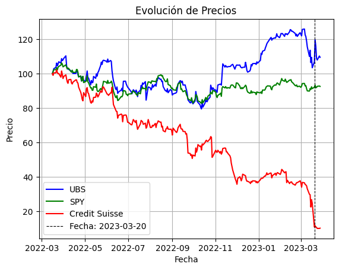

```python
!gdown --id 1FxckF4kvxDsmaU7KKpuJtdQnvhqM9BNe --output spread_data.xlsx
stocks_df = pd.read_excel('spread_data.xlsx')
stocks_df.head()

plt.plot(stocks_df['Date'], stocks_df['UBS'], label='UBS', color='blue')
plt.plot(stocks_df['Date'], stocks_df['SPY'], label='SPY', color='green')
plt.plot(stocks_df['Date'], stocks_df['CS'], label='Credit Suisse', color='red')

plt.axvline(pd.to_datetime("2023-03-20"), color='black', linestyle='--', linewidth=0.8, label=f'Fecha: 2023-03-20')

plt.title('Evolución de Precios')
plt.xlabel('Fecha')
plt.ylabel('Precio')
plt.legend()
plt.grid(True)
plt.show()
```

Los precios de UBS parecen seguir al S&P pero con mayor variabilidad, los saltos positivos como negativos son más grandes para UBS que para el S&P. Para finales de 2022 hasta apróximadamente Febrero del 2023 se nota una tendencia positiva en los precios de UBS y luego una caída del precio quedando en los mismos niveles que en los finales del 2022. Se puede ver que luego del anuncio hubo un aumento de la acción que luego parece haberse corregido en los días posteriores. En el caso de los precios de Credit Suisse vemos que la tendencia desde inicios de 2022 hasta inicios de 2023 fue negativa, parecería no llevar mucha correlación con el S&P. Tiene en el rango del periodo varias caídas pronunciadas, la última siendo la mayor de todas en Marzo del 2023 en adelante.

#### Ejercicio 3.3

Calculen los retornos diarios como la variación porcentual de cada índice.

```python
stocks_df['CS_retorno_diario'] = stocks_df['CS'].pct_change()
stocks_df['UBS_retorno_diario'] = stocks_df['UBS'].pct_change()
stocks_df['SPY_retorno_diario'] = stocks_df['SPY'].pct_change()
stocks_df = stocks_df[stocks_df['Date'] != '2022-03-16']
stocks_df.head()
```

|  | Date | CS | KBWB | SPY | UBS | CS_retorno_diario | UBS_retorno_diario | SPY_retorno_diario |
| --- | --- | --- | --- | --- | --- | --- | --- | --- |
| 1 | 2022-03-17 | 99.072848 | 99.910647 | 101.251087 | 101.327429 | -0.009272 | 0.013274 | 0.012511 |
| 2 | 2022-03-18 | 100.529801 | 99.702176 | 102.360077 | 102.931421 | 0.014706 | 0.015830 | 0.010953 |
| 3 | 2022-03-21 | 100.529801 | 99.256181 | 102.330142 | 103.705745 | 0.000000 | 0.007523 | -0.000292 |
| 4 | 2022-03-22 | 102.251656 | 101.486165 | 103.527544 | 106.194694 | 0.017128 | 0.024000 | 0.011701 |
| 5 | 2022-03-23 | 100.794702 | 98.597667 | 102.194279 | 104.590701 | -0.014249 | -0.015104 | -0.012878 |

#### Ejercicio 3.4

Estimen el modelo presentado previamente utilizando mínimos cuadrados ordinarios entre 17-marzo-2022 y el 23-marzo-2023, y presente los resultados

```python
#Agrego las variables dummy al dataframe
stocks_df['dummy_2023_03_16'] = (stocks_df['Date'] == '2023-03-16').astype(int)
stocks_df['dummy_2023_03_17'] = (stocks_df['Date'] == '2023-03-17').astype(int)
stocks_df['dummy_2023_03_20'] = (stocks_df['Date'] == '2023-03-20').astype(int)
stocks_df['dummy_2023_03_21'] = (stocks_df['Date'] == '2023-03-21').astype(int)
stocks_df['dummy_2023_03_22'] = (stocks_df['Date'] == '2023-03-22').astype(int)
stocks_df['dummy_2023_03_23'] = (stocks_df['Date'] == '2023-03-23').astype(int)

#Calculamos regresión
reg_ubs = smf.ols(formula="UBS_retorno_diario ~ SPY_retorno_diario + dummy_2023_03_16 + dummy_2023_03_17 + dummy_2023_03_20 + dummy_2023_03_21 + dummy_2023_03_22 + dummy_2023_03_23", data=stocks_df).fit()
print(reg_ubs.summary())
```

```
                            OLS Regression Results
==============================================================================
Dep. Variable:     UBS_retorno_diario   R-squared:                       0.554
Model:                            OLS   Adj. R-squared:                  0.542
Method:                 Least Squares   F-statistic:                     44.55
Date:                Wed, 23 Apr 2025   Prob (F-statistic):           1.23e-40
Time:                        02:03:48   Log-Likelihood:                 705.47
No. Observations:                 259   AIC:                            -1395.
Df Residuals:                     251   BIC:                            -1366.
Df Model:                           7
Covariance Type:            nonrobust
======================================================================================
                         coef    std err          t      P>|t|      [0.025      0.975]
--------------------------------------------------------------------------------------
Intercept              0.0008      0.001      0.759      0.449      -0.001       0.003
SPY_retorno_diario     1.0306      0.069     14.846      0.000       0.894       1.167
dummy_2023_03_16       0.0094      0.016      0.583      0.561      -0.022       0.041
dummy_2023_03_17      -0.0438      0.016     -2.704      0.007      -0.076      -0.012
dummy_2023_03_20       0.0223      0.016      1.378      0.169      -0.010       0.054
dummy_2023_03_21       0.1054      0.016      6.509      0.000       0.073       0.137
dummy_2023_03_22      -0.0141      0.016     -0.869      0.386      -0.046       0.018
dummy_2023_03_23      -0.0638      0.016     -3.950      0.000      -0.096      -0.032
==============================================================================
Omnibus:                       73.773   Durbin-Watson:                   2.186
Prob(Omnibus):                  0.000   Jarque-Bera (JB):              609.861
Skew:                          -0.862   Prob(JB):                    3.72e-133
Kurtosis:                      10.317   Cond. No.                         69.3
==============================================================================

Notes:
[1] Standard Errors assume that the covariance matrix of the errors is correctly specified.
```

#### Ejercicio 3.5

Analicen la significatividad individual de los coeficientes, e interprétenlos. ¿Qué porcentaje de variabilidad explica el modelo? ¿Hay un efecto significativo del anuncio de la compra de credit suisse en el precio de UBS en alguno de los días analizados?

- Partimos de considerar que si un p-valor es menor a 0.05, decimos que el coeficiente es significativo. En este ejercicio encontramos 4 coeficientes significativos.

```python
reg_ubs.pvalues
```

|  | 0 |
| --- | --- |
| Intercept | 4.486167e-01 |
| SPY_retorno_diario | 3.248600e-36 |
| dummy_2023_03_16 | 5.605841e-01 |
| dummy_2023_03_17 | 7.318268e-03 |
| dummy_2023_03_20 | 1.694994e-01 |
| dummy_2023_03_21 | 4.075396e-10 |
| dummy_2023_03_22 | 3.856826e-01 |
| dummy_2023_03_23 | 1.014939e-04 |

**dtype:** float64

```python
# Obtener los p-valores de la regresión
p_valores = reg_ubs.pvalues

# Filtrar los coeficientes con p-valor menor a 0.05
coeficientes_significativos = p_valores[p_valores < 0.05]

# Imprimir los coeficientes significativos
print(coeficientes_significativos)
```

```
SPY_retorno_diario    3.248600e-36
dummy_2023_03_17      7.318268e-03
dummy_2023_03_21      4.075396e-10
dummy_2023_03_23      1.014939e-04
dtype: float64
```

- **El modelo explica el 55,4% de lo que pasa con UBS.**

```python
r2 = reg_ubs.rsquared
print("R-cuadrado:", r2)
```

```
R-cuadrado: 0.5540582064497668
```

- ¿El anuncio afectó el precio? ✅ Sí.

Los coeficientes asociados a los días 17, 21 y 23 de marzo presentan p-valores menores a 0.05, lo que indica que son estadísticamente significativos. Esto significa que hubo movimientos inusuales en el precio de la acción de UBS en esas fechas, que no pueden explicarse únicamente por el comportamiento general del mercado.

- 📅 17 de marzo: Se observa un efecto significativo previo al anuncio oficial, lo que sugiere que el mercado podría haber estado anticipando la noticia o reaccionando a rumores.
- 📅 21 y 23 de marzo: Luego del anuncio, el precio de UBS también mostró cambios significativos, lo que refleja una clara reacción del mercado frente a la compra de Credit Suisse.

En conjunto, los resultados confirman que el anuncio tuvo un impacto directo y relevante en el precio de la acción de UBS.